# Sveistrups_Sønderjyder

Morten Aaboe Schelde

2023-12-18

## Loading libraries and the CSV-file

First, I load the necessary libraries. Because of the date format in the csv-file, I will need the package called “lubridate”. Furthermore, I load the package called “ggplot2” which is very important if you want to make visualizations. Then, I read the csv-file.

```r
library(tidyverse)
```

```r
library(lubridate)
library(ggplot2)

Sveistrups_Sønderjyder <- read.csv2("data/Sveistrup_forenklet_UTF8.csv")
```

## Separating the date of baptism into year, month and day

Before working with the data, I must look at the date format. Because of the ISO 8601 format, the dates are written as YYYY-MM-DD. I am interested in the years. Therefor, I must split these dates into year, month and day.

```r
Sveistrups_Sønderjyder$Date_baptism <- as.Date(Sveistrups_Sønderjyder$Date_baptism)

Sveistrups_Sønderjyder <- Sveistrups_Sønderjyder %>%
  separate(Date_baptism, into = c("year","month","day"), sep="-")
```

## Counting and visualizing

Now, it is time for working with the data and investigate the research questions.

Counting the number of baptized children

The first question is: How many children were baptized by Sveistrup? To answer this, I count all the children.

```r
count(Sveistrups_Sønderjyder)
```

```
##    n
## 1 36
```

Counting the number of baptized children in each year

Now, I would like to know how many children were baptized in each year. Therefor, I count, again! A visualization of this could be very useful as an image in the project report. Therefor, I use the function “ggplot” to visualize this. With the continued function “geom_col”, I can change the aesthetics of the visualization, e.g. the x and y-axes respectively. Then, I change the titles of the axes. Furthermore, I change the scale on the y-axis to make the scale of the y-axis more clear to read.

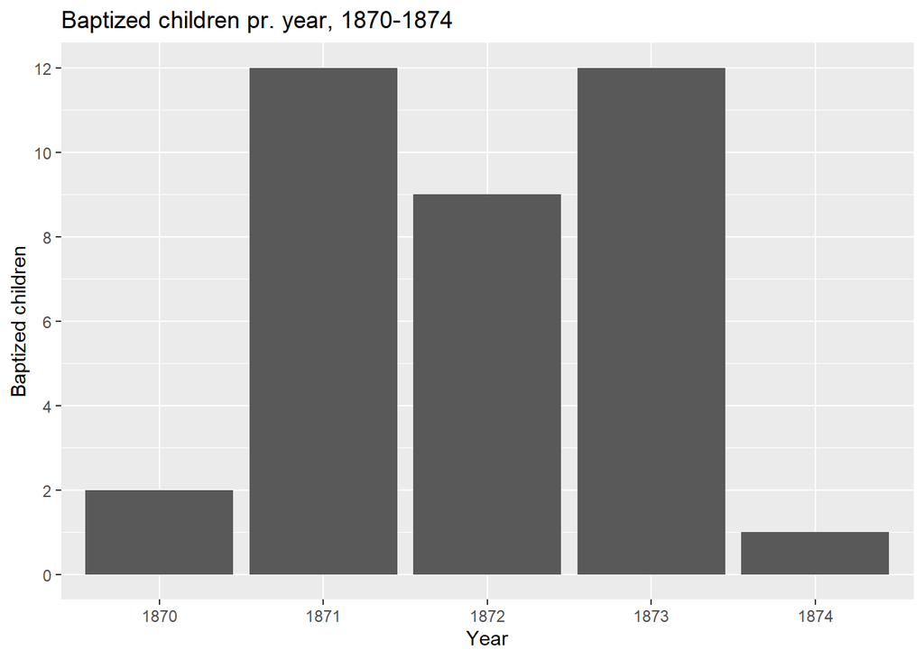

```r
Sveistrups_Sønderjyder %>%
  count(year) %>%
  ggplot()+
  geom_col(aes(x=year, y=n))+
  labs(title = "Baptized children pr. year, 1870-1874", x = "Year", y = "Baptized children")+
  scale_y_continuous(breaks = c(0,2,4,6,8,10,12))
```

Counting the number of families

Now, I count the number of families who left the state church to answer my third research question.

```r
Sveistrups_Sønderjyder %>%
  count(Family_ID)
```

```
##    Family_ID n
## 1          1 3
## 2          2 1
## 3          3 2
## 4          4 2
## 5          5 2
## 6          6 3
## 7          7 1
## 8          8 1
## 9          9 2
## 10        10 2
## 11        11 2
## 12        12 1
## 13        13 1
## 14        14 2
## 15        15 1
## 16        16 1
## 17        17 2
## 18        18 1
## 19        19 1
## 20        20 1
## 21        21 1
## 22        22 1
## 23        23 1
## 24        24 1
```

Counting and visualizing the occupations of the fathers

“Which occupations did the fathers have?” That is my fourth research question. Again, I use the ggplot-function to visualize. In this case, I change the titles of the axes and the scale of the y-axis - as in line 53-54. Furthermore, I set a limit for this scale, between 0 and 30. I also changed the sequence. Therefor it is counted by every second number.

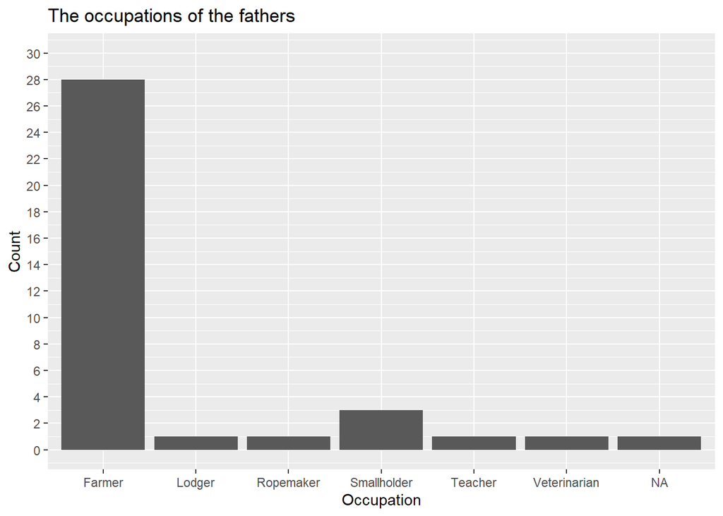

```r
Sveistrups_Sønderjyder %>%
  count(Occupation_father) %>%
  ggplot()+
  geom_col(aes(x=Occupation_father, y=n))+
  labs(title = "The occupations of the fathers", x = "Occupation", y = "Count")+
  scale_y_continuous(limits=c(0,30), breaks = seq(0, 30, by =2))
```

Counting and visualizing the residences of the families

Now, I count the residences of the families. These are registered as the parishes. Again, I change the aesthetics of the visualization.

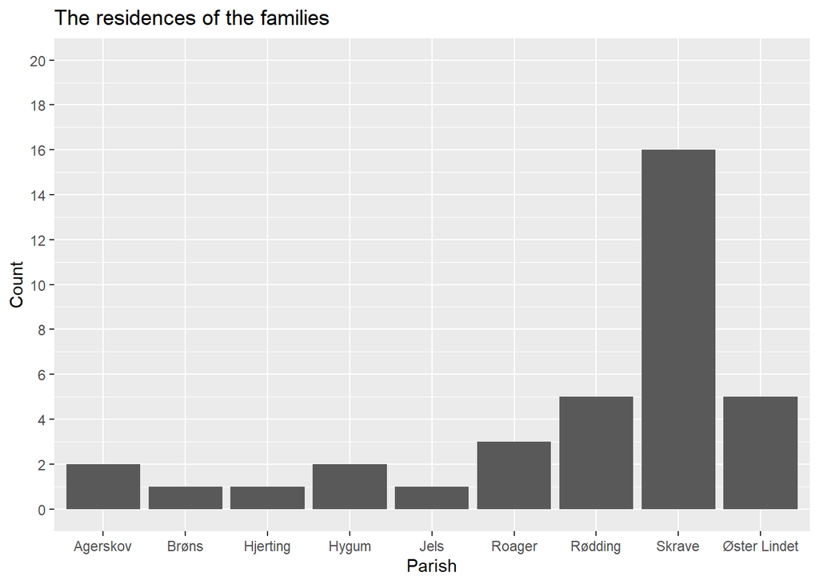

```r
Sveistrups_Sønderjyder %>%
  count(Residence_parish) %>%
  ggplot()+
  geom_col(aes(x=Residence_parish, y=n))+
  labs(title = "The residences of the families", x = "Parish", y = "Count")+
  scale_y_continuous(limits = c(0,20), breaks = seq(0, 20, by =2))
```